# Individual Assignment #2

## Assignment #2: ARIMA Laboratory

### Name: Muskaan Singhania

### EID: ms88283

#### Due: Nov. 29 (Before Class)

#### (40 points)

### Part I. Estimating Growth Potential and Capacity Utilization

Suppose you are working for a firm in the restaurant business looking into the possibility of starting operations in Australia. Your company has already narrowed its focus to five states: (i) Queensland, (ii) Victoria, (iii) New South Wales, (iv) Western Australia, and (v) the Australian Capital Territory. The decision of locations to start operations depend on two factors:

1. **Growth Potential:** More than the size of the market itself, the firm is interested in starting operations in locations with high growth rates. The reasoning behind this decision is that it is easier to gain a foothold in a market that is growing than in one that is stagnant.
2. **Demand Variability:** There are two dimensions to demand variability. First, the change in mean demand from month to month over the year, i.e., the seasonality; and second, the volatility of the demand within each season. This is important as high levels of seasonality and high levels of uncertainty lead to reduced expected expected levels of capacity utilization and lower cash flows from operation.

To aid your analysis, we include in the code box below an ETS analysis of the sales (turnover) of the aggregate restaurant industry in each state. Please base your answers to question (1) and (2) on the results obtained by the analysis below.

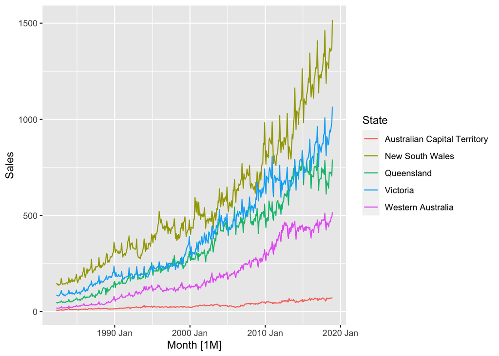

```r
R <- aus_retail %>%
  filter(Industry == "Cafes, restaurants and takeaway food services",
         State == "Australian Capital Territory"|
           State == "Queensland" |
           State == "Victoria" |
           State == "Western Australia" |
           State == "New South Wales" ) %>%
  mutate(Sales = Turnover) %>%
  select(State, Sales)

R %>% autoplot(.var = Sales)
```

```r
m <- R %>% model(me = ETS(Sales))

MC <- m %>% components()

MC %>% filter(State == "Australian Capital Territory") %>% filter(Month >= ym("2017 Dec"))
```

| State | .model | Month | Sales | level | slope | season | remainder |
| --- | --- | --- | --- | --- | --- | --- | --- |
| Australian Capital Territory | me | 2017 Dec | 63.6 | 59.98852 | 0.1524918 | 1.0973329 | -0.102180385 |
| Australian Capital Territory | me | 2018 Jan | 54.9 | 60.19809 | 0.1527651 | 0.9116048 | 0.001371245 |
| Australian Capital Territory | me | 2018 Feb | 59.8 | 63.51161 | 0.1678971 | 0.9211803 | 0.075664681 |
| Australian Capital Territory | me | 2018 Mar | 71.0 | 67.77859 | 0.1875214 | 1.0201030 | 0.092997687 |
| Australian Capital Territory | me | 2018 Apr | 67.3 | 68.81750 | 0.1915974 | 0.9725997 | 0.018097644 |
| Australian Capital Territory | me | 2018 May | 67.6 | 67.93466 | 0.1864536 | 1.0021199 | -0.022493755 |
| Australian Capital Territory | me | 2018 Jun | 67.2 | 68.99165 | 0.1906213 | 0.9685975 | 0.018462715 |
| Australian Capital Territory | me | 2018 Jul | 70.4 | 69.81827 | 0.1936661 | 1.0042652 | 0.013281383 |
| Australian Capital Territory | me | 2018 Aug | 69.2 | 68.81192 | 0.1879210 | 1.0134972 | -0.024762928 |
| Australian Capital Territory | me | 2018 Sep | 68.6 | 68.37128 | 0.1849118 | 1.0074628 | -0.013160843 |

[output cut: 3 more lines]

```r
MC %>% filter(State == "Queensland") %>% filter(Month >= ym("2017 Dec"))
```

| State | .model | Month | Sales | level | slope | season | remainder |
| --- | --- | --- | --- | --- | --- | --- | --- |
| Queensland | me | 2017 Dec | 785.5 | 708.8852 | -0.15164662 | 1.1098067 | -0.004644441 |
| Queensland | me | 2018 Jan | 708.6 | 694.1183 | -0.61114671 | 1.0317810 | -0.030992075 |
| Queensland | me | 2018 Feb | 611.5 | 682.1789 | -0.95774143 | 0.9039423 | -0.024570200 |
| Queensland | me | 2018 Mar | 680.1 | 690.2486 | -0.65355876 | 0.9788788 | 0.019869085 |
| Queensland | me | 2018 Apr | 658.3 | 685.6299 | -0.76635921 | 0.9629461 | -0.008668036 |
| Queensland | me | 2018 May | 665.5 | 680.7949 | -0.88024990 | 0.9804888 | -0.008959926 |
| Queensland | me | 2018 Jun | 641.9 | 673.0472 | -1.08049228 | 0.9586492 | -0.015215328 |
| Queensland | me | 2018 Jul | 721.8 | 698.0303 | -0.23489690 | 1.0150271 | 0.058230407 |
| Queensland | me | 2018 Aug | 725.8 | 709.7425 | 0.14766461 | 1.0140519 | 0.025715579 |
| Queensland | me | 2018 Sep | 719.5 | 715.4804 | 0.32168304 | 1.0016839 | 0.011838797 |

[output cut: 3 more lines]

```r
MC %>% filter(State == "New South Wales") %>% filter(Month >= ym("2017 Dec"))
```

| State | .model | Month | Sales | level | slope | season | remainder |
| --- | --- | --- | --- | --- | --- | --- | --- |
| New South Wales | me | 2017 Dec | 1461.4 | 1286.707 | 3.447773 | 1.1405078 | -0.018055811 |
| New South Wales | me | 2018 Jan | 1295.3 | 1271.632 | 3.340130 | 1.0229881 | -0.018575067 |
| New South Wales | me | 2018 Feb | 1187.6 | 1276.332 | 3.348030 | 0.9301880 | 0.001379556 |
| New South Wales | me | 2018 Mar | 1298.7 | 1300.134 | 3.466897 | 0.9943034 | 0.020679682 |
| New South Wales | me | 2018 Apr | 1288.2 | 1310.717 | 3.508255 | 0.9812559 | 0.007063263 |
| New South Wales | me | 2018 May | 1288.7 | 1307.336 | 3.468217 | 0.9872729 | -0.006782475 |
| New South Wales | me | 2018 Jun | 1265.2 | 1333.208 | 3.598412 | 0.9443294 | 0.022112588 |
| New South Wales | me | 2018 Jul | 1349.5 | 1363.411 | 3.753023 | 0.9841575 | 0.025748842 |
| New South Wales | me | 2018 Aug | 1370.7 | 1386.268 | 3.864044 | 0.9847847 | 0.018078846 |
| New South Wales | me | 2018 Sep | 1354.4 | 1375.871 | 3.781169 | 0.9874002 | -0.013272427 |

[output cut: 3 more lines]

```r
MC %>% filter(State == "Western Australia") %>% filter(Month >= ym("2017 Dec"))
```

| State | .model | Month | Sales | level | slope | season | remainder |
| --- | --- | --- | --- | --- | --- | --- | --- |
| Western Australia | me | 2017 Dec | 512.3 | 478.7444 | 1.222950 | 1.0684761 | 0.022312702 |
| Western Australia | me | 2018 Jan | 454.1 | 468.4103 | 1.171579 | 0.9720009 | -0.032999258 |
| Western Australia | me | 2018 Feb | 424.6 | 462.2062 | 1.138794 | 0.9201629 | -0.021525724 |
| Western Australia | me | 2018 Mar | 466.1 | 454.1121 | 1.097754 | 1.0285973 | -0.027308584 |
| Western Australia | me | 2018 Apr | 451.8 | 447.4121 | 1.063093 | 1.0116464 | -0.023476378 |
| Western Australia | me | 2018 May | 458.1 | 439.0646 | 1.021263 | 1.0457181 | -0.028756963 |
| Western Australia | me | 2018 Jun | 441.1 | 437.8485 | 1.011318 | 1.0079446 | -0.006967393 |
| Western Australia | me | 2018 Jul | 464.6 | 442.1348 | 1.025875 | 1.0500568 | 0.010226905 |
| Western Australia | me | 2018 Aug | 469.9 | 449.6919 | 1.054906 | 1.0435010 | 0.020197809 |
| Western Australia | me | 2018 Sep | 467.6 | 460.6579 | 1.098961 | 1.0130504 | 0.030134131 |

[output cut: 3 more lines]

```r
MC %>% filter(State == "Victoria") %>% filter(Month >= ym("2017 Dec"))
```

| State | .model | Month | Sales | level | slope | season | remainder |
| --- | --- | --- | --- | --- | --- | --- | --- |
| Victoria | me | 2017 Dec | 1008.1 | 894.5664 | 2.053611 | 1.1342554 | -0.018394971 |
| Victoria | me | 2018 Jan | 887.3 | 887.7802 | 1.765035 | 1.0047647 | -0.015041826 |
| Victoria | me | 2018 Feb | 810.6 | 882.2170 | 1.524492 | 0.9228862 | -0.012566461 |
| Victoria | me | 2018 Mar | 909.7 | 894.0352 | 1.778364 | 1.0112958 | 0.017917438 |
| Victoria | me | 2018 Apr | 898.6 | 907.5717 | 2.067576 | 0.9833028 | 0.020192104 |
| Victoria | me | 2018 May | 866.4 | 889.1724 | 1.455818 | 0.9864651 | -0.034425755 |
| Victoria | me | 2018 Jun | 873.1 | 912.6483 | 2.036779 | 0.9445034 | 0.037965180 |
| Victoria | me | 2018 Jul | 916.1 | 922.7419 | 2.217783 | 0.9881783 | 0.013580141 |
| Victoria | me | 2018 Aug | 943.8 | 938.7972 | 2.555521 | 0.9974659 | 0.023018933 |
| Victoria | me | 2018 Sep | 933.8 | 944.0908 | 2.577937 | 0.9875425 | 0.004549976 |

[output cut: 3 more lines]

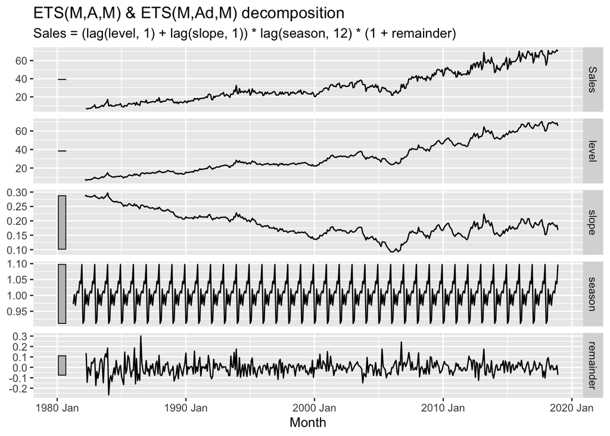

```r
MC %>% filter(State == "Australian Capital Territory") %>% autoplot()
```

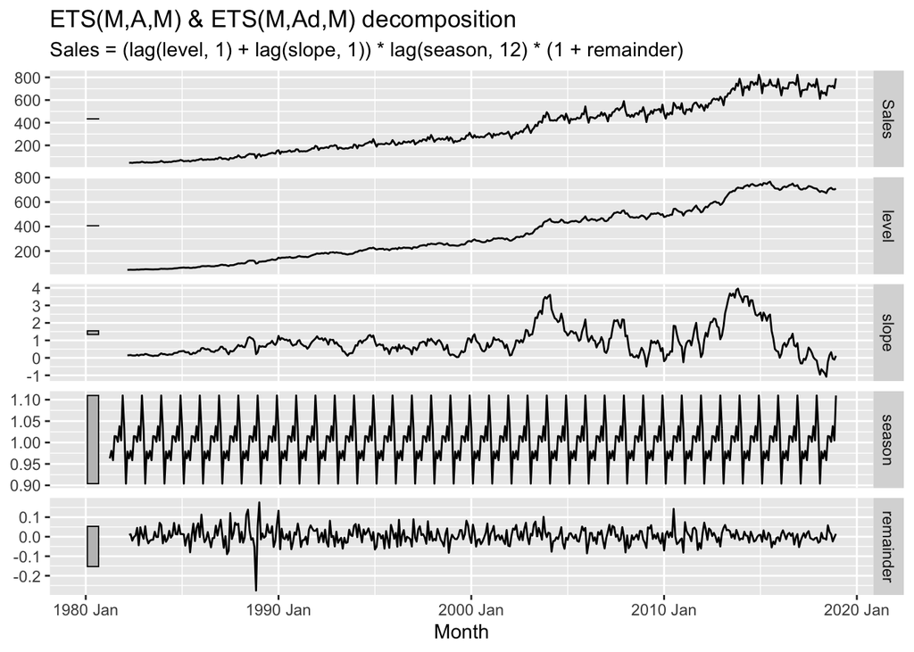

```r
MC %>% filter(State == "Queensland") %>% autoplot()
```

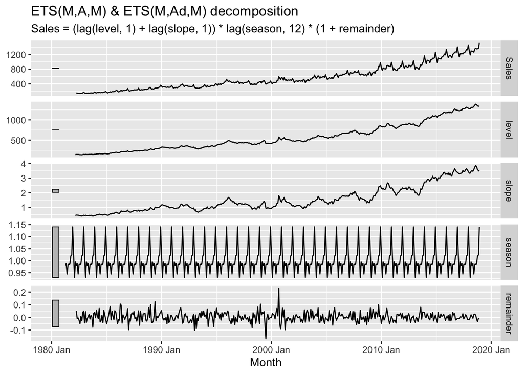

```r
MC %>% filter(State == "New South Wales") %>% autoplot()
```

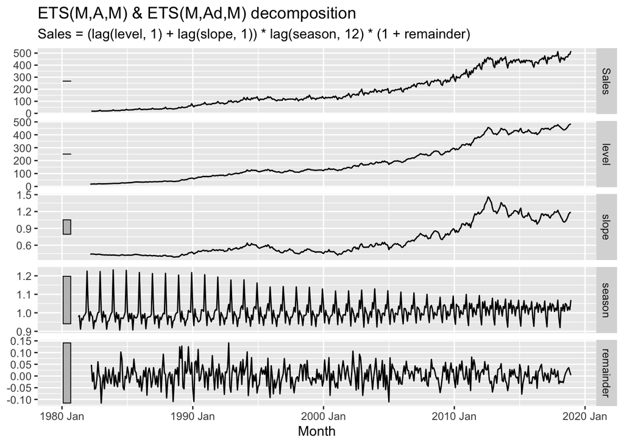

```r
MC %>% filter(State == "Western Australia") %>% autoplot()
```

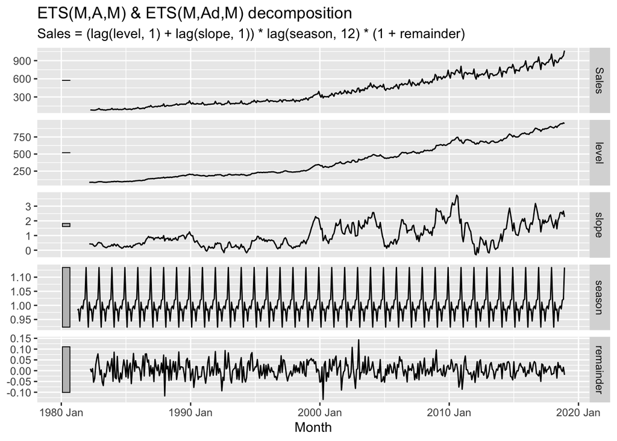

```r
MC %>% filter(State == "Victoria") %>% autoplot()
```

1. **What is the type of growth estimated by the models above for each state?**

Ans: Growth type for the aforementioned states are:

**Queensland**  
Model: ETS(M,Ad,M)  
Growth Type: Multiplicative error, Additive damped trend and Multiplicative seasonality

**New South Wales**  
Model: ETS(M,A,M)  
Growth Type: Multiplicative error, Additive trend and Multiplicative Seasonality

**Western Australia**  
Model: ETS(M,A,M)  
Growth Type: Multiplicative error, Additive trend and Multiplicative Seasonality

**Australian Capital Territory**  
Model: ETS(M,A,M)  
Growth Type: Multiplicative error, Additive trend and Multiplicative Seasonality

**Victoria**  
Model: ETS(M,Ad,M)  
Growth Type: Multiplicative error, Additive damped trend and Multiplicative Seasonality

2. **What are the values of the growth parameters (for each state) at the end of analysis period**?

Ans: The following are the values of the growth parameters:

**Queensland**  
Level: 709.308  
Trend: 0.118  
Seasonality: 1.110

**New South Wales**  
Level: 1332.941  
Trend: 3.468  
Seasonality: 1.141

**Western Australia**  
Level: 483.581  
Trend: 1.186  
Seasonality: 1.069

**Australian Capital Territory**  
Level: 65.415  
Trend: 0.168  
Seasonality: 1.097

**Victoria**  
Level: 946.492  
Trend: 2.269  
Seasonality: 1.134

3. What is the growth rate (expressed as a percentage) of sales experienced by each state over the last twelve months? Calculate this as the percent change in the de-seasonalized level of demand estimated over the last twelve months.

```r
MC %>%
  group_by(State) %>%
  mutate(growth_rate = ((level / lag(level,12)) -1)*100) %>%
  filter(Month == ym("2018 Dec")) %>%
  as_tibble %>%
  select(State, growth_rate) -> mc_growth

mc_growth
```

| State | growth_rate |
| --- | --- |
| Australian Capital Territory | 9.04508211 |
| New South Wales | 3.59321417 |
| Queensland | 0.05956302 |
| Victoria | 5.80461853 |
| Western Australia | 1.01020169 |

4. One measure of operational risk is the effect of variability of mean demand from season to season on capacity utilization. A simple way to estimate this is to calculate for each of the five states $D_{MAX} = \max_m D_m$ where the index $m$ takes values corresponding to the last twelve months. That is, $D_{MAX}$ is the maximum mean level of demand fitted for the last twelve months. Then calculate the monthly metric of mean-forecast-based capacity utilization for each month as
   $$U_m = \frac{D_m}{D_{MAX}} \times
   100,$$
   then, using the monthly mean-based capacity utilization obtain the average mean-forecast-based utilization as $MU = mean(U_m)$ Report the utilization calculation for each of the five states. Summarize your analysis of sales growth potential and mean-variability with a table indicating the annual growth rate and annual average mean-base capacity utilization for each state. Management wants you to pick three of these five states to start operations base only on your analysis. explain your reasoning. Are there any states that are dominated by other states based only on the growth vs. utilization metrics? Explain.

```r
MC %>%
  group_by(State) %>%
  mutate(mean_dem = (lag(level,1)+lag(slope,1))*lag(season,12)) %>%
  filter(Month >= ym("2018 Jan")) %>%
  mutate(max_dem = (max(mean_dem))) %>%
  mutate(util = (mean_dem/max_dem)*100) %>%
  mutate('Average Capacity Utilisation' = mean(util)) -> mc_util
mc_util
```

| State | .model | Month | Sales | level | slope | season | remainder | mean_dem | max_dem | util | Average Capacity Utilisation |
| --- | --- | --- | --- | --- | --- | --- | --- | --- | --- | --- | --- |
| Australian Capital Territory | me | 2018 Jan | 54.9 | 60.19809 | 0.15276505 | 0.9116048 | 0.001371245 | 54.82482 | 75.5625 | 72.55559 | 88.67180 |
| Australian Capital Territory | me | 2018 Feb | 59.8 | 63.51161 | 0.16789713 | 0.9211803 | 0.075664681 | 55.59353 | 75.5625 | 73.57291 | 88.67180 |
| Australian Capital Territory | me | 2018 Mar | 71.0 | 67.77859 | 0.18752142 | 1.0201030 | 0.092997687 | 64.95897 | 75.5625 | 85.96720 | 88.67180 |
| Australian Capital Territory | me | 2018 Apr | 67.3 | 68.81750 | 0.19159744 | 0.9725997 | 0.018097644 | 66.10368 | 75.5625 | 87.48212 | 88.67180 |
| Australian Capital Territory | me | 2018 May | 67.6 | 67.93466 | 0.18645356 | 1.0021199 | -0.022493755 | 69.15557 | 75.5625 | 91.52101 | 88.67180 |
| Australian Capital Territory | me | 2018 Jun | 67.2 | 68.99165 | 0.19062129 | 0.9685975 | 0.018462715 | 65.98180 | 75.5625 | 87.32082 | 88.67180 |
| Australian Capital Territory | me | 2018 Jul | 70.4 | 69.81827 | 0.19366610 | 1.0042652 | 0.013281383 | 69.47725 | 75.5625 | 91.94672 | 88.67180 |
| Australian Capital Territory | me | 2018 Aug | 69.2 | 68.81192 | 0.18792102 | 1.0134972 | -0.024762928 | 70.95711 | 75.5625 | 93.90518 | 88.67180 |
| Australian Capital Territory | me | 2018 Sep | 68.6 | 68.37128 | 0.18491180 | 1.0074628 | -0.013160843 | 69.51487 | 75.5625 | 91.99652 | 88.67180 |
| Australian Capital Territory | me | 2018 Oct | 70.2 | 67.63594 | 0.18050613 | 1.0442259 | -0.019392912 | 71.58831 | 75.5625 | 94.74051 | 88.67180 |

[output cut: 50 more lines]

```r
mc_util %>%
  as_tibble %>%
  group_by(State) %>%
  summarise('Average Capacity Utilisation' = mean(util)) -> mc_util_fin

mc_util_fin
```

| State | Average Capacity Utilisation |
| --- | --- |
| Australian Capital Territory | 88.67180 |
| New South Wales | 86.75189 |
| Queensland | 89.18296 |
| Victoria | 84.36764 |
| Western Australia | 90.64272 |

```r
mc_growth$'Average Capacity Utilisation' <- mc_util_fin$'Average Capacity Utilisation'

mc_growth$ranking_state = rank(-mc_growth$growth_rate)
mc_growth$util_rank = rank(-mc_growth$'Average Capacity Utilisation')
mc_growth$Avg_Rank = mc_growth$ranking_state*0.5 + mc_growth$util_rank*0.5
mc_growth
```

| State | growth_rate | Average Capacity Utilisation | ranking_state | util_rank | Avg_Rank |
| --- | --- | --- | --- | --- | --- |
| Australian Capital Territory | 9.04508211 | 88.67180 | 1 | 3 | 2.0 |
| New South Wales | 3.59321417 | 86.75189 | 3 | 4 | 3.5 |
| Queensland | 0.05956302 | 89.18296 | 5 | 2 | 3.5 |
| Victoria | 5.80461853 | 84.36764 | 2 | 5 | 3.5 |
| Western Australia | 1.01020169 | 90.64272 | 4 | 1 | 2.5 |

Ranking based on growth metric:

1. Australian Capital Territory
2. Victoria
3. New South Wales
4. Western Australia
5. Queensland

Ranking based on utilization metric:

1. Western Australia
2. Queensland
3. Australian Capital Territory
4. New South Wales
5. Victoria

From the above outputted table, the selected states are **Australian Capital Territory, Western Australia and New South Wales**

This selection has been made based on:

1. Average Rank column
2. We see that even though Victoria has promising growth potential, it is lacking when it comes to utilization
3. Similarly, Queensland shows promising utilization but lacking the growth potential
4. Hence, the most intuitive pick for the third state would be New South Wales

### Part II. Estimating Downside Risk in Capacity Utilization

After looking at your analysis and considering a number of additional factors not included in your analysis, management decided to narrow their prospecting to New South Wales, Western Australia and Victoria, and are asking for a more detailed analysis of the capacity utilization risk. To estimate this risk, they are asking you to use the actual state-wide sales level as an index of what would be the company’s sales, and assume that the actual system capacity will be built as the 95% quantile of the forecasted demand. Management is tasking you to estimate the average capacity utilization and the downside capacity utilization risk for each state. The following questions guide you through this analysis:

5. Using the training and testing sets specified below, fit the best ETS and ARIMA models for the sales in each of these three states. Comment on the selection of a forecasting model for each state based on the validity, accuracy and information criteria for each model.

```r
# Break into Training and Testing sets.

S <- R %>%
  filter(State == "New South Wales" |
         State == "Western Australia" |
         State == "Victoria")

TR <- S %>%
  filter(Month >= yearmonth("2000 Jan"),
         Month <= yearmonth("2017 Dec"))
TE <- S %>%
  filter(Month >= yearmonth("2018 Jan"))

model_eval <- TR %>% model(ets_model = ETS(Sales),
                        arima_model = ARIMA(Sales))
model_eval %>% glance()
```

| State | .model | sigma2 | log_lik | AIC | AICc | BIC | MSE | AMSE | MAE | ar_roots | ma_roots |
| --- | --- | --- | --- | --- | --- | --- | --- | --- | --- | --- | --- |
| New South Wales | ets_model | 1.276560e-03 | -1279.6520 | 2595.304 | 2598.776 | 2656.059 | 544.68618 | 906.5405 | 0.02433629 |  |  |
| New South Wales | arima_model | 7.105968e+02 | -960.3375 | 1932.675 | 1933.101 | 1952.584 | NA | NA | NA |  |  |
| Victoria | ets_model | 1.260290e-03 | -1218.6082 | 2473.216 | 2476.688 | 2533.971 | 352.86546 | 547.2196 | 0.02590816 |  |  |
| Victoria | arima_model | 4.247422e+02 | -907.6822 | 1829.364 | 1829.936 | 1852.591 | NA | NA | NA |  |  |
| Western Australia | ets_model | 1.149717e-03 | -1047.0351 | 2130.070 | 2133.542 | 2190.825 | 80.51043 | 127.9762 | 0.02564549 |  |  |
| Western Australia | arima_model | 9.525629e+01 | -755.3057 | 1522.611 | 1523.038 | 1542.520 | NA | NA | NA |  |  |

Based on AIC, AICc and BIC - Arima models seem to performing better for all the three states

```r
forecast_mod <- model_eval %>% forecast(h = 12)

rbind(model_eval %>% accuracy(),
            forecast_mod %>% accuracy(data = TE))
```

| State | .model | .type | ME | RMSE | MAE | MPE | MAPE | MASE | RMSSE | ACF1 |
| --- | --- | --- | --- | --- | --- | --- | --- | --- | --- | --- |
| New South Wales | ets_model | Training | 2.85346614 | 23.338513 | 17.614931 | 0.25935684 | 2.408273 | 0.2641696 | 0.2848580 | 0.0098673134 |
| New South Wales | arima_model | Training | -0.33156720 | 25.586523 | 19.649495 | -0.27608814 | 2.692457 | 0.2946818 | 0.3122961 | -0.0152927580 |
| Victoria | ets_model | Training | 2.43586235 | 18.784714 | 14.610114 | 0.31354654 | 2.581460 | 0.3491149 | 0.3727737 | 0.1520171412 |
| Victoria | arima_model | Training | 0.18365889 | 19.731879 | 15.225174 | -0.07485965 | 2.639147 | 0.3638120 | 0.3915697 | 0.0198619642 |
| Western Australia | ets_model | Training | 0.86130832 | 8.972761 | 6.983501 | 0.26520954 | 2.551286 | 0.2999420 | 0.2960339 | 0.0042634882 |
| Western Australia | arima_model | Training | 0.03355931 | 9.367992 | 7.124440 | -0.15724227 | 2.571401 | 0.3059953 | 0.3090736 | -0.0008409091 |
| New South Wales | arima_model | Test | 7.94329965 | 24.149191 | 18.967058 | 0.56856787 | 1.436014 | NaN | NaN | 0.5115018582 |
| Victoria | arima_model | Test | 9.44055358 | 23.155710 | 19.026820 | 0.89926581 | 2.010926 | NaN | NaN | 0.5447355080 |
| Western Australia | arima_model | Test | -28.98531912 | 30.492370 | 28.985319 | -6.27820334 | 6.278203 | NaN | NaN | 0.6845583515 |
| New South Wales | ets_model | Test | 19.13491083 | 30.111922 | 24.751110 | 1.41275958 | 1.843972 | NaN | NaN | 0.4851633319 |

[output cut: 2 more lines]

Based on Out-of-sample MAPE, Arima Model performs better for Victoria and New South Wales whereas ETS performs better for Western Australia

After listening to your arguments, and considering other subjective factors, your supervisor ask you to select the ARIMA model you obtained for the states of Western Australia and Victoria, but she prefers the ETS model for New South Whales. Use the above models to answer the following questions.

6. Fit the actual models selected as the best ARIMA and ETS (see above) and re-fit these models using all the available data (i.e, the **S** data set), and then prepare a 12-month ahead forecast for each state. Report the forecast and the 80% and 90% confidence intervals for each state.

```r
model_WA = S %>% filter(State=='Western Australia') %>% model(model_ar = ARIMA(Sales ~ pdq(2,0,0) + PDQ(0,1,2)))

model_Vic = S %>% filter(State=='Victoria') %>% model(model_ar = ARIMA(Sales ~ pdq(1,0,1) + PDQ(1,1,2)))

model_SW = S %>% filter(State=='New South Wales') %>% model(model_ets = ETS(Sales ~ error('M') + trend('Ad') +season('M')))

forecast_WA = model_WA %>% forecast(h=12)
forecast_Vic = model_Vic %>% forecast(h=12)
forecast_SW = model_SW %>% forecast(h=12)

f_agg = bind_rows(forecast_WA, forecast_Vic, forecast_SW)
f_agg %>% hilo(level =c(80,90)) %>%
  unpack_hilo("80%") %>% unpack_hilo("90%")
```

| State | .model | Month | Sales | .mean | 80%_lower | 80%_upper | 90%_lower | 90%_upper |
| --- | --- | --- | --- | --- | --- | --- | --- | --- |
| New South Wales | model_ets | 2019 Jan |  | 1363.9880 | 1296.8740 | 1431.1019 | 1277.8481 | 1450.1278 |
| New South Wales | model_ets | 2019 Feb |  | 1240.9285 | 1163.5988 | 1318.2582 | 1141.6769 | 1340.1801 |
| New South Wales | model_ets | 2019 Mar |  | 1327.9437 | 1230.5589 | 1425.3285 | 1202.9516 | 1452.9358 |
| New South Wales | model_ets | 2019 Apr |  | 1313.1615 | 1204.0421 | 1422.2809 | 1173.1083 | 1453.2147 |
| New South Wales | model_ets | 2019 May |  | 1325.0168 | 1203.1144 | 1446.9192 | 1168.5568 | 1481.4769 |
| New South Wales | model_ets | 2019 Jun |  | 1269.8823 | 1142.5456 | 1397.2190 | 1106.4474 | 1433.3172 |
| New South Wales | model_ets | 2019 Jul |  | 1328.8677 | 1185.2681 | 1472.4673 | 1144.5596 | 1513.1758 |
| New South Wales | model_ets | 2019 Aug |  | 1332.7491 | 1178.8703 | 1486.6279 | 1135.2478 | 1530.2504 |
| New South Wales | model_ets | 2019 Sep |  | 1339.4612 | 1175.3263 | 1503.5962 | 1128.7963 | 1550.1261 |
| New South Wales | model_ets | 2019 Oct |  | 1381.7171 | 1202.9945 | 1560.4396 | 1152.3292 | 1611.1049 |

[output cut: 26 more lines]

```r
#Western Australia
WA_avg = f_agg %>% filter(State=='Western Australia') %>% mutate(Quant_95 = quantile(Sales, 0.95), Quant_05 = quantile(Sales, 0.05), CAP=max(Quant_95), DUR=Quant_05/CAP * 100) %>% as_tibble() %>%
  group_by(State) %>% summarise(DURmean = mean(DUR))

#Victoria
Vic_avg = f_agg %>% filter(State=='Victoria') %>% mutate(Quant_95 = quantile(Sales, 0.95), Quant_05 = quantile(Sales, 0.05), CAP=max(Quant_95), DUR=Quant_05/CAP * 100) %>% as_tibble() %>%
  group_by(State) %>% summarise(DURmean = mean(DUR))

#New South Wales
NSW_avg = f_agg %>% filter(State=='New South Wales') %>% mutate(Quant_95 = quantile(Sales, 0.95), Quant_05 = quantile(Sales, 0.05), CAP=max(Quant_95), DUR=Quant_05/CAP * 100)  %>% as_tibble() %>%
  group_by(State) %>% summarise(DURmean = mean(DUR))

#Aggregate
rbind(WA_avg, Vic_avg, NSW_avg)
```

| State | DURmean |
| --- | --- |
| Western Australia | 82.95008 |
| Victoria | 81.10831 |
| New South Wales | 64.16464 |

8. After examining your analysis in Question (7) management made two decisions: First, Building capacity up to the 95% quantile of demand was too considered too risky and affected expected profitability, and ask you to redefine the capacity at the 70% quantile. and second, they decided that the downside risk at the 5% quantile was to conservative, and ask you to re-calculate the figures you reported using a downside demand estimated at the 10% quantile of the demand forecast and repeat your calculations in Question 7. Comment on the likely effect of the capacity reduction decision on the capacity utilization at the median demand. Explain the difference with the utilization quantities estimated in Question (4)

```r
bind_rows(forecast_WA,forecast_Vic,forecast_SW) %>%
  mutate(Quant_70 = quantile(Sales, 0.70)) %>%
  group_by(State) %>%
  mutate(max_quant_70 = max(Quant_70)) %>%
  mutate(DUR = quantile(Sales, 0.10)/max_quant_70) %>%
  as_tibble %>%
  group_by(State) %>%
  summarise(Mean_DUR = mean(DUR)*100)
```

| State | Mean_DUR |
| --- | --- |
| New South Wales | 74.09598 |
| Victoria | 84.74369 |
| Western Australia | 87.18319 |

1. Average downside utilization increase when the capacity was at 70% quantile and downside risk was raised to 10% from the previous value of 5%
2. In conclusion, reduction in capacity led to increase in capacity utilization and median demand

```r
bind_rows(forecast_WA,forecast_Vic,forecast_SW) %>%
  mutate(Quant_70 = quantile(Sales, 0.70)) %>%
  group_by(State) %>%
  mutate(max_quant_70 = max(Quant_70)) %>%
  mutate(DUR = quantile(Sales, 0.50)/max_quant_70) %>%
  as_tibble %>%
  group_by(State) %>%
  summarise(Mean_DUR = mean(DUR)*100)
```

| State | Mean_DUR |
| --- | --- |
| New South Wales | 82.51651 |
| Victoria | 87.84697 |
| Western Australia | 90.61206 |